# R ASSIGNMENT

Olympia Mugarura

2023-11-17

# SECTION A

Reading metaFile.csv into R

```r
setwd("C:/Users/OLYMPIA/Downloads/fwdmsb7102bioconductorandrprogrammingassignment")
library(dplyr)
```

```r
library("ggplot2")
metadata <- read.csv("metaFile.csv")
print(metadata)
```

```
##    sample_id Participant Treatment
## 1   sample_1           C         4
## 2   sample_2           B         3
## 3   sample_3           B         2
## 4   sample_4           C         1
## 5   sample_5           C         3
## 6   sample_6           A         4
## 7   sample_7           B         0
## 8   sample_8           A         1
## 9   sample_9           B         4
## 10 sample_10           C         0
## 11 sample_11           A         2
## 12 sample_12           A         3
## 13 sample_13           B         1
## 14 sample_14           C         2
```

[output cut: 36 more lines]

1. number of variables/columns and records/rows

```r
ncol(metadata)
```

```
## [1] 3
```

```r
nrow(metadata)
```

```
## [1] 50
```

2. number of samples obtained for each level of treatment

```r
table(metadata$Treatment)
```

```
##
##  0  1  2  3  4
##  9 10 10 11 10
```

3. number of samples obtained for each participate

```r
table(metadata$Participant)
```

```
##
##  A  B  C
## 15 17 18
```

4. extracting records for samples obtained at treatment levels 0, 2 and 4

```r
metadata[metadata$Treatment %in% c(0, 2, 4),]
```

```
##    sample_id Participant Treatment
## 1   sample_1           C         4
## 3   sample_3           B         2
## 6   sample_6           A         4
## 7   sample_7           B         0
## 9   sample_9           B         4
## 10 sample_10           C         0
## 11 sample_11           A         2
## 14 sample_14           C         2
## 15 sample_15           A         0
## 16 sample_16           C         4
## 18 sample_18           B         2
## 21 sample_21           A         4
## 22 sample_22           B         0
## 24 sample_24           B         4
## 25 sample_25           C         0
## 26 sample_26           A         2
## 29 sample_29           C         2
## 30 sample_30           A         0
## 31 sample_31           C         4
## 33 sample_33           B         2
## 36 sample_36           A         4
## 37 sample_37           B         0
## 39 sample_39           B         4
## 40 sample_40           C         0
## 41 sample_41           A         2
## 44 sample_44           C         2
## 45 sample_45           A         0
## 46 sample_46           C         4
## 48 sample_48           B         2
```

22. extracting records for samples obtained from participant A and C

```r
metadata %>% filter(Participant %in% c("A", "C"))
```

```
##    sample_id Participant Treatment
## 1   sample_1           C         4
## 2   sample_4           C         1
## 3   sample_5           C         3
## 4   sample_6           A         4
## 5   sample_8           A         1
## 6  sample_10           C         0
## 7  sample_11           A         2
## 8  sample_12           A         3
## 9  sample_14           C         2
## 10 sample_15           A         0
## 11 sample_16           C         4
## 12 sample_19           C         1
## 13 sample_20           C         3
## 14 sample_21           A         4
```

[output cut: 19 more lines]

6. number of samples under each participant groups per treatment level

```r
table(metadata$Participant, metadata$Treatment)
```

```
##
##     0 1 2 3 4
##   A 3 3 3 3 3
##   B 3 3 4 4 3
##   C 3 4 3 4 4
```

# SECTION B

```r
setwd("C:/Users/OLYMPIA/Downloads/fwdmsb7102bioconductorandrprogrammingassignment")
Assignmentdata <- read.csv("AssignmentFile.csv")
print(Assignmentdata)
```

```
##      samples      Conc1     Conc2      Conc3
## 1   sample_1 5.93804869 2.2877765  3.2487625
## 2   sample_2 3.39846291 4.0508845  3.2359883
## 3   sample_3 1.94647521 1.2918230  1.2597982
## 4   sample_4 1.75043775 4.5088147  2.6153558
## 5   sample_5 2.90319389 2.6006057  1.6662130
## 6   sample_6 0.74662991 3.5212946  1.3361532
## 7   sample_7 2.61412606 1.7075223  2.9077324
## 8   sample_8 2.86823250 0.6855859  0.7057831
## 9   sample_9 4.25332693 1.5380970  4.1286548
## 10 sample_10 2.53152856 1.4914619  2.8437762
## 11 sample_11 2.02469134 1.0988479  3.0460737
## 12 sample_12 1.68888486 1.5382037  1.5721820
## 13 sample_13 0.07948294 1.8417749  5.4324201
## 14 sample_14 2.35002162 2.8437762  3.5107200
```

[output cut: 36 more lines]

1. number of variables and records

```r
ncol(Assignmentdata)
```

```
## [1] 4
```

```r
nrow(Assignmentdata)
```

```
## [1] 50
```

2. computing the average concentration for each of the concentrations

```r
colMeans(Assignmentdata[, c("Conc1","Conc2","Conc3")])
```

```
##    Conc1    Conc2    Conc3
## 2.235910 2.631801 2.579690
```

3. computing the average Conc for each sample

```r
rowMeans(Assignmentdata[c("Conc1", "Conc2", "Conc3")])
```

```
##  [1] 3.824863 3.561779 1.499365 2.958203 2.390004 1.868026 2.409794 1.419867
##  [9] 3.306693 2.288922 2.056538 1.599757 2.451226 2.901506 3.258827 1.753767
## [17] 2.443834 2.657674 1.782624 2.034364 1.998999 2.163061 2.544692 2.452164
## [25] 2.092057 3.003388 3.313401 1.765348 1.624170 3.037058 2.448267 2.038269
## [33] 2.833067 1.957261 1.668823 2.192923 2.616311 3.646680 2.841996 2.949213
## [41] 3.229693 2.329251 3.211285 2.842079 2.998275 2.744949 1.683616 2.672564
## [49] 2.434259 2.322598
```

4. extending assignmentdata by introducing new variable “Concmean”

```r
Assignmentdata$Concmean <- rowMeans(Assignmentdata[c("Conc1", "Conc2", "Conc3")])
print(Assignmentdata)
```

```
##      samples      Conc1     Conc2      Conc3 Concmean
## 1   sample_1 5.93804869 2.2877765  3.2487625 3.824863
## 2   sample_2 3.39846291 4.0508845  3.2359883 3.561779
## 3   sample_3 1.94647521 1.2918230  1.2597982 1.499365
## 4   sample_4 1.75043775 4.5088147  2.6153558 2.958203
## 5   sample_5 2.90319389 2.6006057  1.6662130 2.390004
## 6   sample_6 0.74662991 3.5212946  1.3361532 1.868026
## 7   sample_7 2.61412606 1.7075223  2.9077324 2.409794
## 8   sample_8 2.86823250 0.6855859  0.7057831 1.419867
## 9   sample_9 4.25332693 1.5380970  4.1286548 3.306693
## 10 sample_10 2.53152856 1.4914619  2.8437762 2.288922
## 11 sample_11 2.02469134 1.0988479  3.0460737 2.056538
## 12 sample_12 1.68888486 1.5382037  1.5721820 1.599757
## 13 sample_13 0.07948294 1.8417749  5.4324201 2.451226
## 14 sample_14 2.35002162 2.8437762  3.5107200 2.901506
```

[output cut: 36 more lines]

6. obtaining the basic statistics

```r
summary(Assignmentdata)
```

```
##    samples              Conc1             Conc2            Conc3
##  Length:50          Min.   :0.07948   Min.   :0.6856   Min.   :-0.2755
##  Class :character   1st Qu.:1.64835   1st Qu.:1.8380   1st Qu.: 1.8432
##  Mode  :character   Median :2.22227   Median :2.5963   Median : 2.6424
##                     Mean   :2.23591   Mean   :2.6318   Mean   : 2.5797
##                     3rd Qu.:2.72488   3rd Qu.:3.2873   3rd Qu.: 3.1898
##                     Max.   :5.93805   Max.   :4.7706   Max.   : 5.4324
##     Concmean
##  Min.   :1.420
##  1st Qu.:2.035
##  Median :2.446
##  Mean   :2.482
##  3rd Qu.:2.937
##  Max.   :3.825
```

```r
sapply(Assignmentdata[,2:5], sd)
```

```
##     Conc1     Conc2     Conc3  Concmean
## 1.0384617 0.9653108 1.1169179 0.6018165
```

```r
sapply(Assignmentdata[,2:5], var)
```

```
##     Conc1     Conc2     Conc3  Concmean
## 1.0784026 0.9318250 1.2475056 0.3621831
```

# SECTION C

1. removing variables Conc1, Conc2 and Conc3 from the data frame

```r
Assignmentdata <- subset(Assignmentdata, select = -c(Conc1, Conc2, Conc3))
print(Assignmentdata)
```

```
##      samples Concmean
## 1   sample_1 3.824863
## 2   sample_2 3.561779
## 3   sample_3 1.499365
## 4   sample_4 2.958203
## 5   sample_5 2.390004
## 6   sample_6 1.868026
## 7   sample_7 2.409794
## 8   sample_8 1.419867
## 9   sample_9 3.306693
## 10 sample_10 2.288922
## 11 sample_11 2.056538
## 12 sample_12 1.599757
## 13 sample_13 2.451226
## 14 sample_14 2.901506
```

[output cut: 36 more lines]

2. merging information in the two data frames concentration with metadata

```r
merged_data <- merge(metadata, Assignmentdata, by.x = "sample_id", by.y = "samples")
print(merged_data)
```

```
##    sample_id Participant Treatment Concmean
## 1   sample_1           C         4 3.824863
## 2  sample_10           C         0 2.288922
## 3  sample_11           A         2 2.056538
## 4  sample_12           A         3 1.599757
## 5  sample_13           B         1 2.451226
## 6  sample_14           C         2 2.901506
## 7  sample_15           A         0 3.258827
## 8  sample_16           C         4 1.753767
## 9  sample_17           B         3 2.443834
## 10 sample_18           B         2 2.657674
## 11 sample_19           C         1 1.782624
## 12  sample_2           B         3 3.561779
## 13 sample_20           C         3 2.034364
## 14 sample_21           A         4 1.998999
```

[output cut: 36 more lines]

3. checking the size of combined data-frame

```r
size <- dim(merged_data)
print(paste("Number of rows:", size[1]))
```

```
## [1] "Number of rows: 50"
```

```r
print(paste("Number of columns:", size[2]))
```

```
## [1] "Number of columns: 4"
```

```r
print (colnames(merged_data))
```

```
## [1] "sample_id"   "Participant" "Treatment"   "Concmean"
```

```r
print(head(merged_data))
```

```
##   sample_id Participant Treatment Concmean
## 1  sample_1           C         4 3.824863
## 2 sample_10           C         0 2.288922
## 3 sample_11           A         2 2.056538
## 4 sample_12           A         3 1.599757
## 5 sample_13           B         1 2.451226
## 6 sample_14           C         2 2.901506
```

4. extracting records for samples for participants B and C obtained at treatment levels 2,3 and 4 and Assigning it “participantsBC”

```r
participantsBC <- subset(merged_data, Participant %in% c("B", "C") & Treatment %in% c(2, 3, 4))
print(participantsBC)
```

```
##    sample_id Participant Treatment Concmean
## 1   sample_1           C         4 3.824863
## 6  sample_14           C         2 2.901506
## 8  sample_16           C         4 1.753767
## 9  sample_17           B         3 2.443834
## 10 sample_18           B         2 2.657674
## 12  sample_2           B         3 3.561779
## 13 sample_20           C         3 2.034364
## 17 sample_24           B         4 2.452164
## 22 sample_29           C         2 1.624170
## 23  sample_3           B         2 1.499365
## 25 sample_31           C         4 2.448267
## 26 sample_32           B         3 2.038269
## 27 sample_33           B         2 2.833067
## 29 sample_35           C         3 1.668823
## 33 sample_39           B         4 2.841996
## 39 sample_44           C         2 2.842079
## 41 sample_46           C         4 2.744949
## 42 sample_47           B         3 1.683616
## 43 sample_48           B         2 2.672564
## 45  sample_5           C         3 2.390004
## 46 sample_50           C         3 2.322598
## 50  sample_9           B         4 3.306693
```

22. computing the average concentration for participants B and C under treatments 2, 3 and 4

```r
avg_concentration <- participantsBC %>% group_by(Participant, Treatment) %>% summarize(AvgConcentration = mean(Concmean, na.rm = TRUE))
print(avg_concentration)
```

```
## # A tibble: 6 × 3
## # Groups:   Participant [2]
##   Participant Treatment AvgConcentration
##   <chr>           <int>            <dbl>
## 1 B                   2             2.42
## 2 B                   3             2.43
## 3 B                   4             2.87
## 4 C                   2             2.46
## 5 C                   3             2.10
## 6 C                   4             2.69
```

6. changing treatment levels from 0,1,2,3,4 to “very-low”, “low”, “moderate”, “high”, “very-high” using for loop

```r
merged_data
```

```
##    sample_id Participant Treatment Concmean
## 1   sample_1           C         4 3.824863
## 2  sample_10           C         0 2.288922
## 3  sample_11           A         2 2.056538
## 4  sample_12           A         3 1.599757
## 5  sample_13           B         1 2.451226
## 6  sample_14           C         2 2.901506
## 7  sample_15           A         0 3.258827
## 8  sample_16           C         4 1.753767
## 9  sample_17           B         3 2.443834
## 10 sample_18           B         2 2.657674
## 11 sample_19           C         1 1.782624
## 12  sample_2           B         3 3.561779
## 13 sample_20           C         3 2.034364
## 14 sample_21           A         4 1.998999
```

[output cut: 36 more lines]

```r
for (c in 1:ncol(merged_data)){
  for (r in 1:nrow(merged_data)){
    value = merged_data[r,c]
    if (value == 0){
      merged_data[r, c] = "Very Low"
    } else if (value == 1){
      merged_data[r, c] = "Low"
    } else if (value == 2){
      merged_data[r, c] = "Moderate"
    } else if (value == 3){
      merged_data[r, c] = "High"
    } else if (value == 4){
      merged_data[r, c] = "Very High"
    }
  }
}
merged_data
```

```
##    sample_id Participant Treatment Concmean
## 1   sample_1           C Very High 3.824863
## 2  sample_10           C  Very Low 2.288922
## 3  sample_11           A  Moderate 2.056538
## 4  sample_12           A      High 1.599757
## 5  sample_13           B       Low 2.451226
## 6  sample_14           C  Moderate 2.901506
## 7  sample_15           A  Very Low 3.258827
## 8  sample_16           C Very High 1.753767
## 9  sample_17           B      High 2.443834
## 10 sample_18           B  Moderate 2.657674
## 11 sample_19           C       Low 1.782624
## 12  sample_2           B      High 3.561779
## 13 sample_20           C      High 2.034364
## 14 sample_21           A Very High 1.998999
```

[output cut: 36 more lines]

7. a sapply() function to change treatment levels from 0,1,2,3,4 to ”very-low”, ”low”, ”moderate”, ”high”, ”very-high” respectively

```r
labels_function <- function(x) {
  labels <- ifelse(x==0, "very low",
                   ifelse(x==1, "low",
                          ifelse(x==2, "moderate",
                                 ifelse(x==3, "high",
                                        ifelse(x==4, "very high", NA)))))
  return(labels)
}

merged_data$Treatment <- sapply(merged_data$Treatment, labels_function)
merged_data
```

```
##    sample_id Participant Treatment Concmean
## 1   sample_1           C        NA 3.824863
## 2  sample_10           C        NA 2.288922
## 3  sample_11           A        NA 2.056538
## 4  sample_12           A        NA 1.599757
## 5  sample_13           B        NA 2.451226
## 6  sample_14           C        NA 2.901506
## 7  sample_15           A        NA 3.258827
## 8  sample_16           C        NA 1.753767
## 9  sample_17           B        NA 2.443834
## 10 sample_18           B        NA 2.657674
## 11 sample_19           C        NA 1.782624
## 12  sample_2           B        NA 3.561779
## 13 sample_20           C        NA 2.034364
## 14 sample_21           A        NA 1.998999
```

[output cut: 36 more lines]

# SECTION D

```r
setwd("C:/Users/OLYMPIA/Downloads/fwdmsb7102bioconductorandrprogrammingassignment")
statsFile <- read.csv("statsFile.csv")
print(statsFile)
```

```
##          X      BMI       BP Gender Status Location
## 1     P_ 1 3.306331 1.848332   Male      1        C
## 2     P_ 2 3.144198 1.803189 Female      0        C
## 3     P_ 3 3.268586 1.837923 Female      1        B
## 4     P_ 4 3.175555 1.812009   Male      1        C
## 5     P_ 5 3.084312 1.786221 Female      1        A
## 6     P_ 6 3.227014 1.826389 Female      1        C
## 7     P_ 7 2.810668 1.706505   Male      1        A
## 8     P_ 8 3.080841 1.785232   Male      1        B
## 9     P_ 9 3.127907 1.798589   Male      1        C
## 10   P_ 10 2.986719 1.758213 Female      1        B
## 11   P_ 11 2.877521 1.726326 Female      0        B
## 12   P_ 12 3.059652 1.779186 Female      1        B
## 13   P_ 13 2.984433 1.757551 Female      0        B
## 14   P_ 14 3.425850 1.880905   Male      1        B
```

[output cut: 306 more lines]

Question 1

The method and technique used is calculating Pearson correlation coefficient between BMI and BP and comparing the means and variances of BMI and BP.

```r
cor(statsFile$BMI,statsFile$BP)
```

```
## [1] 0.9997509
```

```r
cor.test(statsFile$BMI, statsFile$BP)
```

```
##
##  Pearson's product-moment correlation
##
## data:  statsFile$BMI and statsFile$BP
## t = 798.75, df = 318, p-value < 2.2e-16
## alternative hypothesis: true correlation is not equal to 0
## 95 percent confidence interval:
##  0.9996895 0.9998001
## sample estimates:
##       cor
## 0.9997509
```

```r
cor.test(statsFile$BMI, statsFile$BP, method = "pearson")
```

```
##
##  Pearson's product-moment correlation
##
## data:  statsFile$BMI and statsFile$BP
## t = 798.75, df = 318, p-value < 2.2e-16
## alternative hypothesis: true correlation is not equal to 0
## 95 percent confidence interval:
##  0.9996895 0.9998001
## sample estimates:
##       cor
## 0.9997509
```

```r
?cor.test
```

```
## starting httpd help server ... done
```

```r
cov(statsFile$BMI, statsFile$BP)
```

```
## [1] 0.01065146
```

```r
cov(statsFile$BMI, statsFile$BP) / (sd(statsFile$BMI) * sd(statsFile$BP))
```

```
## [1] 0.9997509
```

comparison of means

```r
mean(statsFile$BMI)
```

```
## [1] 3.185907
```

```r
mean(statsFile$BP)
```

```
## [1] 1.814074
```

```r
?t.test
t.test(statsFile$BMI, statsFile$BP)
```

```
##
##  Welch Two Sample t-test
##
## data:  statsFile$BMI and statsFile$BP
## t = 121.36, df = 369.13, p-value < 2.2e-16
## alternative hypothesis: true difference in means is not equal to 0
## 95 percent confidence interval:
##  1.349605 1.394060
## sample estimates:
## mean of x mean of y
##  3.185907  1.814074
```

comparison of variances

```r
var(statsFile$BMI)
```

```
## [1] 0.03789084
```

```r
var(statsFile$BP)
```

```
## [1] 0.002995712
```

```r
?var.test
var.test(statsFile$BMI, statsFile$BP)
```

```
##
##  F test to compare two variances
##
## data:  statsFile$BMI and statsFile$BP
## F = 12.648, num df = 319, denom df = 319, p-value < 2.2e-16
## alternative hypothesis: true ratio of variances is not equal to 1
## 95 percent confidence interval:
##  10.15190 15.75872
## sample estimates:
## ratio of variances
##           12.64836
```

Visualization is produced by a Scatter plot with regression line

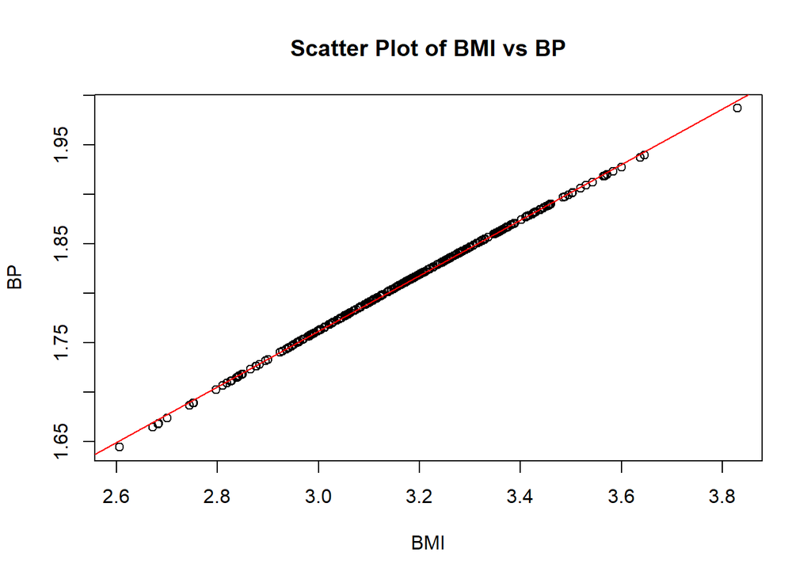

```r
plot(statsFile$BMI, statsFile$BP, main = "Scatter Plot of BMI vs BP", xlab = "BMI", ylab = "BP")
abline(lm(statsFile$BP ~ statsFile$BMI), col = "red")
```

Question 2

The method used is Chi-Square Test of Independence and the technique is by conducting a chi-square test to examine the association between disease status and gender.

```r
chisq.test(table(statsFile$Status, statsFile$Gender))
```

```
##
##  Pearson's Chi-squared test with Yates' continuity correction
##
## data:  table(statsFile$Status, statsFile$Gender)
## X-squared = 0.86632, df = 1, p-value = 0.352
```

```r
table(statsFile$Status, statsFile$Gender)
```

```
##
##     Female Male
##   0    100   65
##   1     85   70
```

visualization is produced by a mosaic plot

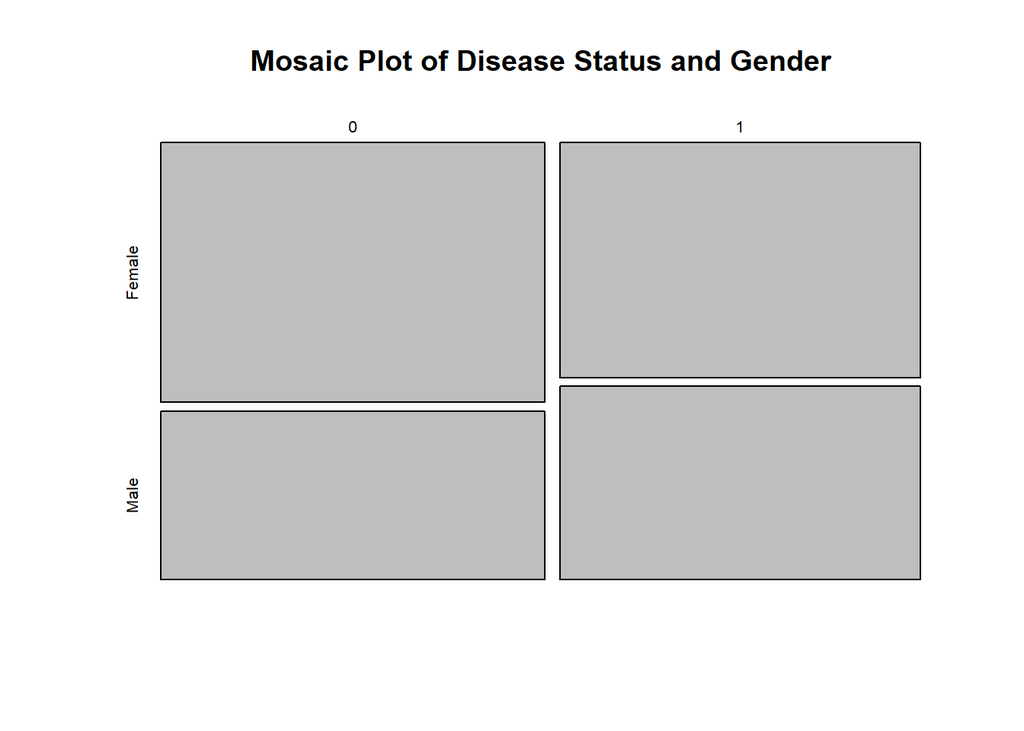

```r
mosaicplot(table (statsFile$Status, statsFile$Gender), main = "Mosaic Plot of Disease Status and Gender")
```

Question 3

A linear regression model with BMI as the predictor and BP as the response variable is used as a technique.

```r
linear_model <- lm(BP ~ BMI, data = statsFile)
linear_model
```

```
##
## Call:
## lm(formula = BP ~ BMI, data = statsFile)
##
## Coefficients:
## (Intercept)          BMI
##      0.9185       0.2811
```

```r
summary(linear_model)
```

```
##
## Call:
## lm(formula = BP ~ BMI, data = statsFile)
##
## Residuals:
##        Min         1Q     Median         3Q        Max
## -0.0080845 -0.0001705  0.0004430  0.0007507  0.0008477
##
## Coefficients:
##              Estimate Std. Error t value Pr(>|t|)
## (Intercept) 0.9184871  0.0011233   817.6   <2e-16 ***
## BMI         0.2811090  0.0003519   798.7   <2e-16 ***
## ---
## Signif. codes:  0 '***' 0.001 '**' 0.01 '*' 0.05 '.' 0.1 ' ' 1
##
## Residual standard error: 0.001224 on 318 degrees of freedom
## Multiple R-squared:  0.9995, Adjusted R-squared:  0.9995
## F-statistic: 6.38e+05 on 1 and 318 DF,  p-value: < 2.2e-16
```

visualization is produced by constructing a scatter plot with a regression line

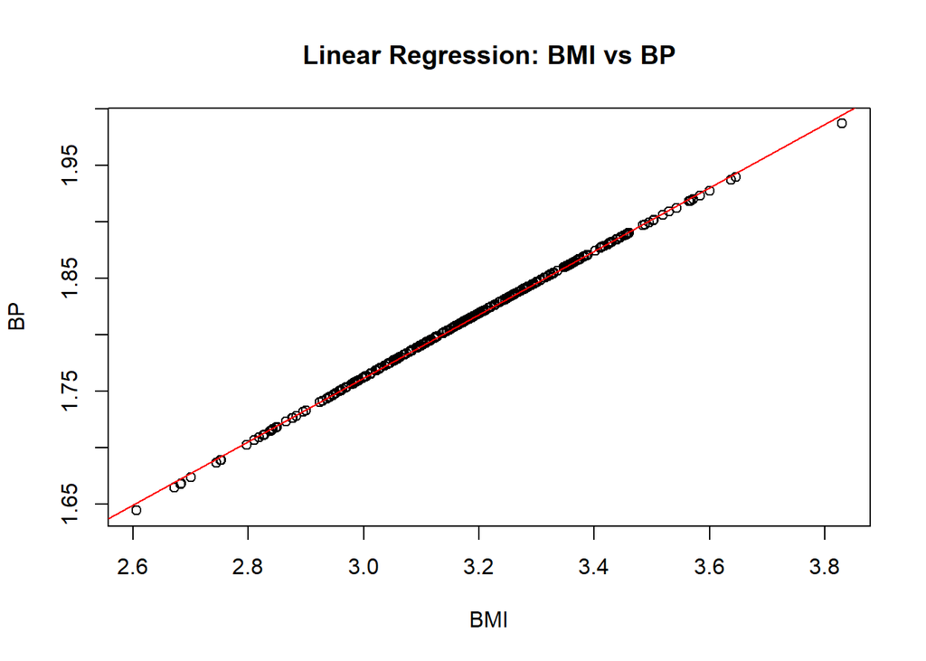

```r
plot(statsFile$BMI, statsFile$BP, main = "Linear Regression: BMI vs BP", xlab = "BMI", ylab = "BP")
abline(linear_model, col = "red")
```

Interpretation

```r
summary(linear_model)
```

```
##
## Call:
## lm(formula = BP ~ BMI, data = statsFile)
##
## Residuals:
##        Min         1Q     Median         3Q        Max
## -0.0080845 -0.0001705  0.0004430  0.0007507  0.0008477
##
## Coefficients:
##              Estimate Std. Error t value Pr(>|t|)
## (Intercept) 0.9184871  0.0011233   817.6   <2e-16 ***
## BMI         0.2811090  0.0003519   798.7   <2e-16 ***
## ---
## Signif. codes:  0 '***' 0.001 '**' 0.01 '*' 0.05 '.' 0.1 ' ' 1
##
## Residual standard error: 0.001224 on 318 degrees of freedom
## Multiple R-squared:  0.9995, Adjusted R-squared:  0.9995
## F-statistic: 6.38e+05 on 1 and 318 DF,  p-value: < 2.2e-16
```

Question 4

Approach 1

mean, median and Variance

```r
statsFile %>% group_by(Location) %>% summarize(mean = mean(BMI), median = median(BMI))
```

```
## # A tibble: 3 × 3
##   Location  mean median
##   <chr>    <dbl>  <dbl>
## 1 A         3.18   3.21
## 2 B         3.21   3.19
## 3 C         3.17   3.17
```

```r
statsFile %>% group_by(Location) %>% summarize(variance = var(BMI))
```

```
## # A tibble: 3 × 2
##   Location variance
##   <chr>       <dbl>
## 1 A          0.0369
## 2 B          0.0395
## 3 C          0.0367
```

visualization (histogram)

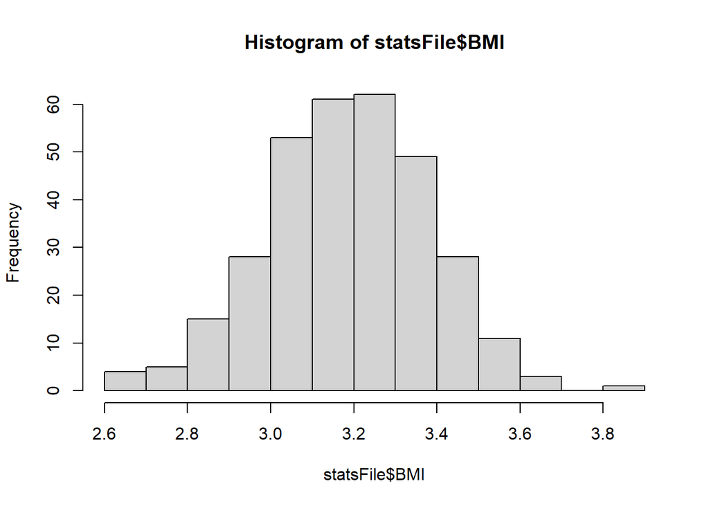

```r
hist(statsFile$BMI)
```

Approach 2

Performing a one-way ANOVA to test whether there is any statistically significant differences in BMI among difference sampling locations.

```r
anov_result <- aov(BMI~Location, statsFile)
anov_result
```

```
## Call:
##    aov(formula = BMI ~ Location, data = statsFile)
##
## Terms:
##                  Location Residuals
## Sum of Squares   0.096678 11.990500
## Deg. of Freedom         2       317
##
## Residual standard error: 0.1944863
## Estimated effects may be unbalanced
```

visualization (boxplot)

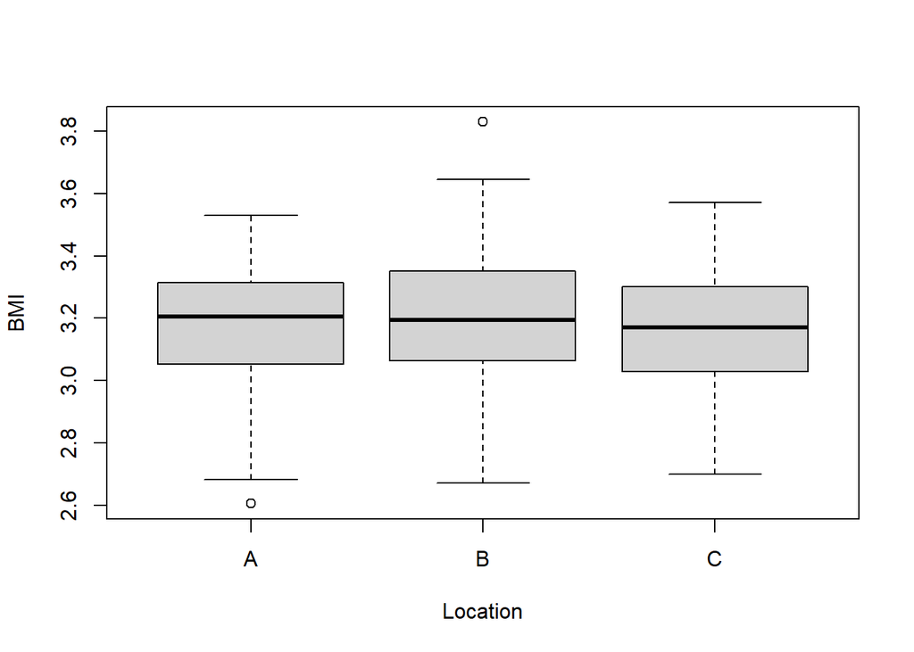

```r
boxplot(BMI ~ Location, data = statsFile)
```

Interpretation of ANOVA results.

```r
summary(anov_result)
```

```
##              Df Sum Sq Mean Sq F value Pr(>F)
## Location      2  0.097 0.04834   1.278   0.28
## Residuals   317 11.991 0.03782
```

Question 5

Building a logistic regression model with disease status as the binary response variable and BMI and BP as predictors.

```r
logistic_model <- glm(Status ~ BMI + BP, data = statsFile, family = "binomial")
logistic_model
```

```
##
## Call:  glm(formula = Status ~ BMI + BP, family = "binomial", data = statsFile)
##
## Coefficients:
## (Intercept)          BMI           BP
##      -11.64        -4.15        13.67
##
## Degrees of Freedom: 319 Total (i.e. Null);  317 Residual
## Null Deviance:       443.3
## Residual Deviance: 443   AIC: 449
```

visualization

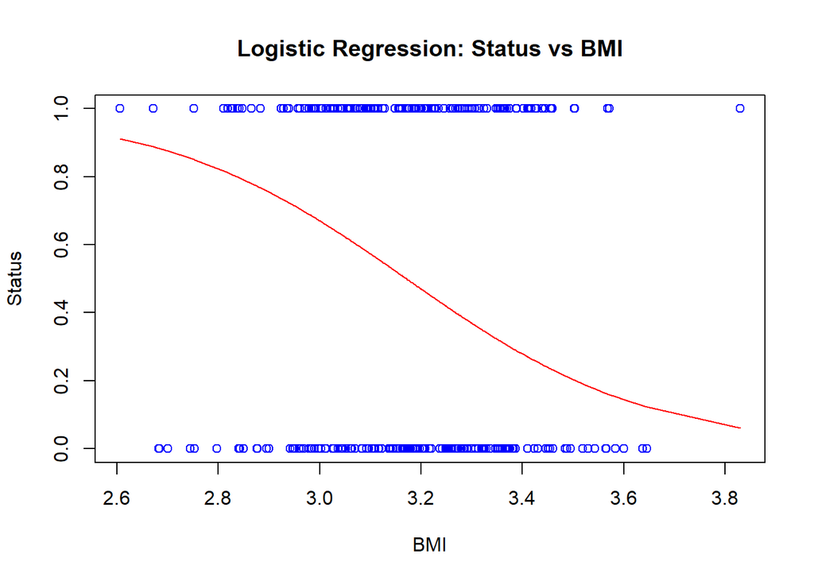

```r
plot(statsFile$BMI, statsFile$Status, main = "Logistic Regression: Status vs BMI", xlab = "BMI", ylab = "Status", col = "blue")
lines(sort(statsFile$BMI), predict(logistic_model, newdata = data.frame(BMI = sort(statsFile$BMI), BP = mean(statsFile$BP)), type = "response"), col = "red")
```

Interpretation

```r
summary(logistic_model)
```

```
##
## Call:
## glm(formula = Status ~ BMI + BP, family = "binomial", data = statsFile)
##
## Coefficients:
##             Estimate Std. Error z value Pr(>|z|)
## (Intercept)   -11.64      84.53  -0.138    0.890
## BMI            -4.15      25.88  -0.160    0.873
## BP             13.67      92.02   0.149    0.882
##
## (Dispersion parameter for binomial family taken to be 1)
##
##     Null deviance: 443.30  on 319  degrees of freedom
## Residual deviance: 442.99  on 317  degrees of freedom
## AIC: 448.99
##
## Number of Fisher Scoring iterations: 3
```